# Study3 Analysis

Investigating the influence of the agent’s Sex on the Side-Effect Effect

Bradley Kennedy

# Study Information

This preregistered study was a online study conducted through Qualtrics. The study investigated how intention is viewed. That is, whether or not an action was planned. Additionally, it investigated how much particular actions deserve praise or blame.

In the study, vignettes were presented to participants. These vignettes varied with the sex of the main character (agent). Additionally, the side-effect was varied between helpful and harmful. For example vignettes, see the OSF repository.

Preregistration, materials, analysis code and a copy of the anonymised data will be made publically available on the Open Science Framework, links below.

OSF Repository: https://osf.io/jes79/  
OSF Preregistration: https://osf.io/cha3p

# R Set-up

Current R Version: 4.1.0

Check if required packages need to be installed, if so, install

```r
list_of_packages<-c("tidyverse", "plyr", "dplyr", "here", "ordinal", "emmeans", "Hmisc")
new.packages <-
  list_of_packages[!(list_of_packages %in% installed.packages()[,"Package"])]
if(length(new.packages))install.packages(new.packages)

lapply(list_of_packages, library, character.only = TRUE)
```

Check for package updates from cloud.r-project.org

```r
update.packages(ask=FALSE, repos = "https://cloud.r-project.org")
```

Import Data & Set variables

```r
s3data <- read_csv(here("DataWrangling","cleaned_s3data.csv"), col_types =
                     cols(List = col_factor(levels = c("1", "2", "3", "4")),
                          Question = col_factor(levels = c("int", "pb")),
                          Sex = col_factor(levels = c("male", "female")),
                          SEValence = col_factor(levels = c("help", "harm"))))

# Plot data set-up
PlotData <- s3data
PlotData$SEValence <- PlotData$SEValence %>%
  as.factor() %>%
  revalue(c("help"="Helpful", "harm"="Harmful"))
PlotData$Sex <- PlotData$Sex %>%
  as.factor() %>%
  revalue(c("male"="Male", "female"="Female"))

s3data$Age <- as.numeric(s3data$Age)
s3data$Gender <- tolower(s3data$Gender)
s3data$Gender <- as.factor(s3data$Gender)
s3data$Student_status <- as.factor(s3data$Student_status)
s3data$Job <- as.factor(s3data$Job)

# Filters for (1) Blame/Praise and (2) Intentionality for the main analysis
filterPB <- s3data$Question == "pb"
filterInt <- s3data$Question == "int"

# This creates the ordered factor for the Rating variable which is Likert scale
s3data$Rating <- as.ordered(s3data$Rating)

# Creates factors for the random effects
s3data$Participant <- as.factor(s3data$Participant)
s3data$Item <- as.factor(s3data$Item)

# This centres the fixed factors using deviation coding
contrasts(s3data$Sex) <- matrix(c(.5, -.5))
contrasts(s3data$SEValence) <- matrix(c(.5, -.5))
```

# Analysis

## Cumulative Link Mixed Models

Christensen, R. H. B. (2019). ordinal - Regression Models for Ordinal Data. R package version 2019.12-10. https://CRAN.R-project.org/package=ordinal.

### Praise Blame model

```r
PB_Model <- clmm(Rating ~ Sex * SEValence + (1 + Sex * SEValence | Participant) +
                   (1 + Sex * SEValence | Item), data = s3data[filterPB,])
summary(PB_Model)
```

```
## Cumulative Link Mixed Model fitted with the Laplace approximation
##
## formula: Rating ~ Sex * SEValence + (1 + Sex * SEValence | Participant) +
##     (1 + Sex * SEValence | Item)
## data:    s3data[filterPB, ]
##
##  link  threshold nobs logLik   AIC     niter       max.grad cond.H
##  logit flexible  3200 -4899.33 9856.66 8890(96835) 7.25e-03 8.8e+04
##
## Random effects:
##  Groups      Name                    Variance Std.Dev. Corr
##  Participant (Intercept)             6.05834  2.4614
##              Sexfemale               0.05290  0.2300   -0.994
##              SEValenceharm           9.08117  3.0135   -0.815  0.744
##              Sexfemale:SEValenceharm 0.05889  0.2427    0.998 -0.984 -0.851
##  Item        (Intercept)             0.17066  0.4131
##              Sexfemale               1.00010  1.0001   -0.950
##              SEValenceharm           0.39155  0.6257   -0.649  0.386
##              Sexfemale:SEValenceharm 0.75848  0.8709    0.915 -0.864 -0.539
## Number of groups:  Participant 100,  Item 32
##
## Coefficients:
##                  Estimate Std. Error z value Pr(>|z|)
## Sex1             0.003511   0.146535   0.024    0.981
## SEValence1      -2.920848   0.324248  -9.008   <2e-16 ***
## Sex1:SEValence1 -0.060982   0.245025  -0.249    0.803
## ---
## Signif. codes:  0 '***' 0.001 '**' 0.01 '*' 0.05 '.' 0.1 ' ' 1
##
## Threshold coefficients:
##     Estimate Std. Error z value
## 0|1 -4.14710    0.18474 -22.448
## 1|2 -2.59283    0.16892 -15.349
## 2|3 -1.22570    0.16271  -7.533
## 3|4  0.03965    0.16089   0.246
## 4|5  1.57268    0.16258   9.673
## 5|6  3.08863    0.16958  18.213
```

```r
# This produces the pairwise comparisons for the Praise Blame Model for the interaction of the Agent's Sex (Sex) and Side Effect Valence (SEValence)
emmeans(PB_Model, pairwise ~ Sex * SEValence, adjust = "none")
```

```
## $emmeans
##  Sex    SEValence emmean    SE  df asymp.LCL asymp.UCL
##  male   help      -0.930 0.272 Inf     -1.46    -0.396
##  female help      -0.903 0.265 Inf     -1.42    -0.382
##  male   harm       2.022 0.219 Inf      1.59     2.451
##  female harm       1.988 0.218 Inf      1.56     2.415
##
## Confidence level used: 0.95
##
## $contrasts
##  contrast                  estimate    SE  df z.ratio p.value
##  male help - female help     -0.027 0.214 Inf  -0.126  0.8996
##  male help - male harm       -2.951 0.350 Inf  -8.430  <.0001
##  male help - female harm     -2.917 0.354 Inf  -8.236  <.0001
##  female help - male harm     -2.924 0.357 Inf  -8.182  <.0001
##  female help - female harm   -2.890 0.343 Inf  -8.424  <.0001
##  male harm - female harm      0.034 0.165 Inf   0.206  0.8368
```

```r
# This produces the confidence intervals for the main effects and the interaction for the Praise Blame Model
confint(PB_Model)
```

```
##                      2.5 %     97.5 %
## 0|1             -4.5091945 -3.7850126
## 1|2             -2.9239059 -2.2617474
## 2|3             -1.5445950 -0.9067972
## 3|4             -0.2757022  0.3549944
## 4|5              1.2540242  1.8913456
## 5|6              2.7562571  3.4210109
## Sex1            -0.2836931  0.2907153
## SEValence1      -3.5563616 -2.2853338
## Sex1:SEValence1 -0.5412224  0.4192589
```

### Intentionality model

```r
Int_Model <- clmm(Rating ~ Sex * SEValence + (1 + Sex * SEValence | Participant) +
                    (1 + Sex * SEValence | Item), data = s3data[filterInt,])

summary(Int_Model)
```

```
## Cumulative Link Mixed Model fitted with the Laplace approximation
##
## formula: Rating ~ Sex * SEValence + (1 + Sex * SEValence | Participant) +
##     (1 + Sex * SEValence | Item)
## data:    s3data[filterInt, ]
##
##  link  threshold nobs logLik   AIC     niter       max.grad cond.H
##  logit flexible  3200 -4753.93 9565.85 7298(80284) 3.21e-03 4.8e+04
##
## Random effects:
##  Groups      Name                    Variance Std.Dev. Corr
##  Participant (Intercept)             5.725249 2.39275
##              Sexfemale               0.007454 0.08634  -0.502
##              SEValenceharm           9.466374 3.07675  -0.670 -0.305
##              Sexfemale:SEValenceharm 0.001258 0.03547   0.989 -0.368 -0.773
##  Item        (Intercept)             0.126495 0.35566
##              Sexfemale               0.381279 0.61748  -0.309
##              SEValenceharm           0.867791 0.93155  -0.907 -0.052
##              Sexfemale:SEValenceharm 0.753616 0.86811   0.897 -0.600 -0.627
## Number of groups:  Participant 100,  Item 32
##
## Coefficients:
##                 Estimate Std. Error z value Pr(>|z|)
## Sex1              0.0322     0.1342   0.240    0.810
## SEValence1       -3.2458     0.3531  -9.193   <2e-16 ***
## Sex1:SEValence1   0.1284     0.2585   0.497    0.619
## ---
## Signif. codes:  0 '***' 0.001 '**' 0.01 '*' 0.05 '.' 0.1 ' ' 1
##
## Threshold coefficients:
##     Estimate Std. Error z value
## 0|1  -3.8337     0.2054 -18.662
## 1|2  -2.1728     0.1942 -11.190
## 2|3  -0.4998     0.1901  -2.629
## 3|4   0.5700     0.1901   2.999
## 4|5   2.2247     0.1934  11.501
## 5|6   3.9886     0.2039  19.561
```

```r
# This produces the pairwise comparisons for the Intentionality Model for the interaction of the Agent's Sex (Sex) and Side Effect Valence (SEValence)
emmeans(Int_Model, pairwise ~ Sex * SEValence, adjust = "none")
```

```
## $emmeans
##  Sex    SEValence emmean    SE  df asymp.LCL asymp.UCL
##  male   help       -1.62 0.265 Inf     -2.14     -1.10
##  female help       -1.72 0.280 Inf     -2.27     -1.17
##  male   harm        1.56 0.284 Inf      1.00      2.12
##  female harm        1.59 0.261 Inf      1.08      2.10
##
## Confidence level used: 0.95
##
## $contrasts
##  contrast                  estimate    SE  df z.ratio p.value
##  male help - female help     0.0964 0.172 Inf   0.561  0.5748
##  male help - male harm      -3.1815 0.380 Inf  -8.363  <.0001
##  male help - female harm    -3.2135 0.352 Inf  -9.116  <.0001
##  female help - male harm    -3.2780 0.401 Inf  -8.168  <.0001
##  female help - female harm  -3.3100 0.371 Inf  -8.911  <.0001
##  male harm - female harm    -0.0320 0.200 Inf  -0.160  0.8726
```

```r
# This produces the confidence intervals for the main effects and the interaction for the Intentionality Model
confint(Int_Model)
```

```
##                      2.5 %     97.5 %
## 0|1             -4.2362970 -3.4310453
## 1|2             -2.5534161 -1.7922541
## 2|3             -0.8724906 -0.1271490
## 3|4              0.1974687  0.9425886
## 4|5              1.8456099  2.6038842
## 5|6              3.5889448  4.3882543
## Sex1            -0.2307634  0.2951722
## SEValence1      -3.9377462 -2.5537548
## Sex1:SEValence1 -0.3781996  0.6350581
```

### Null model comparisons

```r
PB_null <- clmm(Rating ~ 1 + (1 + Sex * SEValence | Participant) +
                  (1 + Sex * SEValence | Item),
                data = s3data[filterPB,])

Int_null_reduced <- clmm(Rating ~ 1 + (1 + Sex + SEValence | Participant) +
                   (1 + Sex + SEValence | Item),
                 data = s3data[filterInt,])

# Create new version of Int_Model to compare to the reduced null model
Int_Model_toCompare <- clmm(Rating ~ Sex * SEValence + (1 + Sex + SEValence | Participant) +
                    (1 + Sex + SEValence | Item),
                    data = s3data[filterInt,])

# Comparisons with null models
anova(PB_null, PB_Model)
```

```
## Likelihood ratio tests of cumulative link models:
##
##          formula:
## PB_null  Rating ~ 1 + (1 + Sex * SEValence | Participant) + (1 + Sex * SEValence | Item)
## PB_Model Rating ~ Sex * SEValence + (1 + Sex * SEValence | Participant) + (1 + Sex * SEValence | Item)
##          link: threshold:
## PB_null  logit flexible
## PB_Model logit flexible
##
##          no.par    AIC  logLik LR.stat df Pr(>Chisq)
## PB_null      26 9913.2 -4930.6
## PB_Model     29 9856.7 -4899.3  62.504  3  1.715e-13 ***
## ---
## Signif. codes:  0 '***' 0.001 '**' 0.01 '*' 0.05 '.' 0.1 ' ' 1
```

```r
anova(Int_null_reduced, Int_Model_toCompare)
```

```
## Likelihood ratio tests of cumulative link models:
##
##                     formula:
## Int_null_reduced    Rating ~ 1 + (1 + Sex + SEValence | Participant) + (1 + Sex + SEValence | Item)
## Int_Model_toCompare Rating ~ Sex * SEValence + (1 + Sex + SEValence | Participant) + (1 + Sex + SEValence | Item)
##                     link: threshold:
## Int_null_reduced    logit flexible
## Int_Model_toCompare logit flexible
##
##                     no.par    AIC  logLik LR.stat df Pr(>Chisq)
## Int_null_reduced        18 9612.8 -4788.4
## Int_Model_toCompare     21 9555.4 -4756.7  63.466  3  1.068e-13 ***
## ---
## Signif. codes:  0 '***' 0.001 '**' 0.01 '*' 0.05 '.' 0.1 ' ' 1
```

### Main effect models

Models showing the main effects of agent sex and side effect valence only (but no interaction) for each of Praise/Blame and then Intentionality. Each model is immediately followed by a comparison of the main-effects only model with the final model (that includes the interaction).

```r
PB_Model_main <- clmm(Rating ~ Sex + SEValence +
                        (1 + Sex + SEValence | Participant) +
                   (1 + Sex + SEValence | Item), data = s3data[filterPB,])

summary(PB_Model_main)
```

```
## Cumulative Link Mixed Model fitted with the Laplace approximation
##
## formula: Rating ~ Sex + SEValence + (1 + Sex + SEValence | Participant) +
##     (1 + Sex + SEValence | Item)
## data:    s3data[filterPB, ]
##
##  link  threshold nobs logLik   AIC     niter       max.grad cond.H
##  logit flexible  3200 -4903.98 9847.96 4369(47095) 4.18e-04 1.8e+02
##
## Random effects:
##  Groups      Name          Variance Std.Dev. Corr
##  Participant (Intercept)   5.68333  2.3840
##              Sexfemale     0.01047  0.1023   -0.938
##              SEValenceharm 8.41570  2.9010   -0.799  0.541
##  Item        (Intercept)   0.11739  0.3426
##              Sexfemale     0.35034  0.5919   -0.276
##              SEValenceharm 0.46945  0.6852   -0.695 -0.213
## Number of groups:  Participant 100,  Item 32
##
## Coefficients:
##            Estimate Std. Error z value Pr(>|z|)
## Sex1        0.02821    0.13681   0.206    0.837
## SEValence1 -2.84496    0.32913  -8.644   <2e-16 ***
## ---
## Signif. codes:  0 '***' 0.001 '**' 0.01 '*' 0.05 '.' 0.1 ' ' 1
##
## Threshold coefficients:
##     Estimate Std. Error z value
## 0|1  -4.1448     0.1866 -22.213
## 1|2  -2.5945     0.1709 -15.178
## 2|3  -1.2315     0.1648  -7.473
## 3|4   0.0316     0.1630   0.194
## 4|5   1.5648     0.1646   9.508
## 5|6   3.0806     0.1715  17.965
```

```r
anova(PB_Model_main, PB_Model)
```

```
## Likelihood ratio tests of cumulative link models:
##
##               formula:
## PB_Model_main Rating ~ Sex + SEValence + (1 + Sex + SEValence | Participant) + (1 + Sex + SEValence | Item)
## PB_Model      Rating ~ Sex * SEValence + (1 + Sex * SEValence | Participant) + (1 + Sex * SEValence | Item)
##               link: threshold:
## PB_Model_main logit flexible
## PB_Model      logit flexible
##
##               no.par    AIC  logLik LR.stat df Pr(>Chisq)
## PB_Model_main     20 9848.0 -4904.0
## PB_Model          29 9856.7 -4899.3  9.3004  9       0.41
```

```r
Int_Model_main <- clmm(Rating ~ Sex + SEValence +
                         (1 + Sex + SEValence | Participant) +
                    (1 + Sex + SEValence | Item), data = s3data[filterInt,])

summary(Int_Model_main)
```

```
## Cumulative Link Mixed Model fitted with the Laplace approximation
##
## formula: Rating ~ Sex + SEValence + (1 + Sex + SEValence | Participant) +
##     (1 + Sex + SEValence | Item)
## data:    s3data[filterInt, ]
##
##  link  threshold nobs logLik   AIC     niter       max.grad cond.H
##  logit flexible  3200 -4756.68 9553.36 3308(36169) 1.78e-03 2.3e+02
##
## Random effects:
##  Groups      Name          Variance Std.Dev. Corr
##  Participant (Intercept)   5.638802 2.3746
##              Sexfemale     0.006872 0.0829   -0.243
##              SEValenceharm 9.302977 3.0501   -0.666 -0.562
##  Item        (Intercept)   0.094336 0.3071
##              Sexfemale     0.274375 0.5238    0.391
##              SEValenceharm 0.695814 0.8342   -0.910 -0.450
## Number of groups:  Participant 100,  Item 32
##
## Coefficients:
##            Estimate Std. Error z value Pr(>|z|)
## Sex1        0.07973    0.13147   0.606    0.544
## SEValence1 -3.17953    0.35285  -9.011   <2e-16 ***
## ---
## Signif. codes:  0 '***' 0.001 '**' 0.01 '*' 0.05 '.' 0.1 ' ' 1
##
## Threshold coefficients:
##     Estimate Std. Error z value
## 0|1  -3.8185     0.2057 -18.559
## 1|2  -2.1595     0.1947 -11.092
## 2|3  -0.4883     0.1908  -2.560
## 3|4   0.5803     0.1907   3.043
## 4|5   2.2330     0.1940  11.511
## 5|6   3.9944     0.2044  19.544
```

```r
anova(Int_Model_main, Int_Model)
```

```
## Likelihood ratio tests of cumulative link models:
##
##                formula:
## Int_Model_main Rating ~ Sex + SEValence + (1 + Sex + SEValence | Participant) + (1 + Sex + SEValence | Item)
## Int_Model      Rating ~ Sex * SEValence + (1 + Sex * SEValence | Participant) + (1 + Sex * SEValence | Item)
##                link: threshold:
## Int_Model_main logit flexible
## Int_Model      logit flexible
##
##                no.par    AIC  logLik LR.stat df Pr(>Chisq)
## Int_Model_main     20 9553.4 -4756.7
## Int_Model          29 9565.9 -4753.9  5.5079  9      0.788
```

### Plots

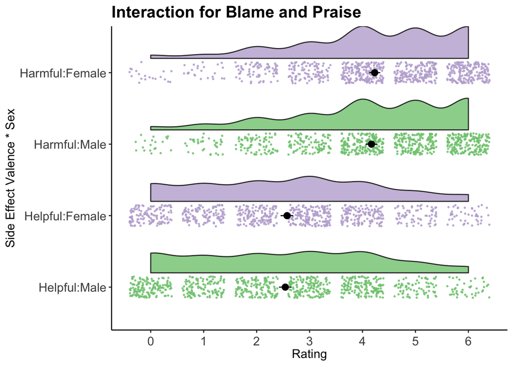

```r
# These two lines create the filters for (1) Blame/Praise and (2) Intentionality for plotting
filterPB2 <-PlotData$Question == "pb"
filterInt2 <-PlotData$Question == "int"

# This is the code for the raincloud plots
source("https://gist.githubusercontent.com/benmarwick/2a1bb0133ff568cbe28d/raw/fb53bd97121f7f9ce947837ef1a4c65a73bffb3f/geom_flat_violin.R")
raincloud_theme = theme(text = element_text(size = 12), axis.title.x = element_text(size = 12),
                        axis.title.y = element_text(size = 12), axis.text = element_text(size = 12),
                        axis.text.x = element_text(vjust = 0.5), legend.title = element_text(size = 12),
                        legend.text = element_text(size=12), legend.position = "right",
                        plot.title = element_text(lineheight=.8, face = "bold", size = 16),
                        panel.border = element_blank(), panel.grid.minor = element_blank(),
                        panel.grid.major = element_blank(),
                        axis.line.x = element_line(colour = 'black', size = 0.5, linetype = 'solid'),
                        axis.line.y = element_line(colour = 'black', size = 0.5, linetype = 'solid'))

# This is the code to create the raincloud plot for the Blame/Praise data
PBRain <- ggplot(data = PlotData[filterPB2,],
                 aes(y = Rating, x = PlotData[filterPB2,]$SEValence : PlotData[filterPB2,]$Sex,
                     fill = Sex)) +
  geom_flat_violin(position = position_nudge(x = .2, y = 0), alpha = .8, trim=TRUE) +
  geom_point(aes(y = Rating, color = Sex),
             position = position_jitter(width = .15), size = .4, alpha = 0.8) +
  expand_limits(x = 3) +
  guides(fill = FALSE) +
  guides(color = FALSE) +
  scale_color_brewer(palette = "Accent") +
  scale_fill_brewer(palette = "Accent") +
  coord_flip() + theme_bw() +
  raincloud_theme +
  labs(x = "Side Effect Valence * Sex", title = "Interaction for Blame and Praise") +
  scale_y_continuous(breaks = seq(0,6,by = 1)) +
  stat_summary(fun.data = "mean_cl_boot", colour = "black", size = .5)

PBRain
```

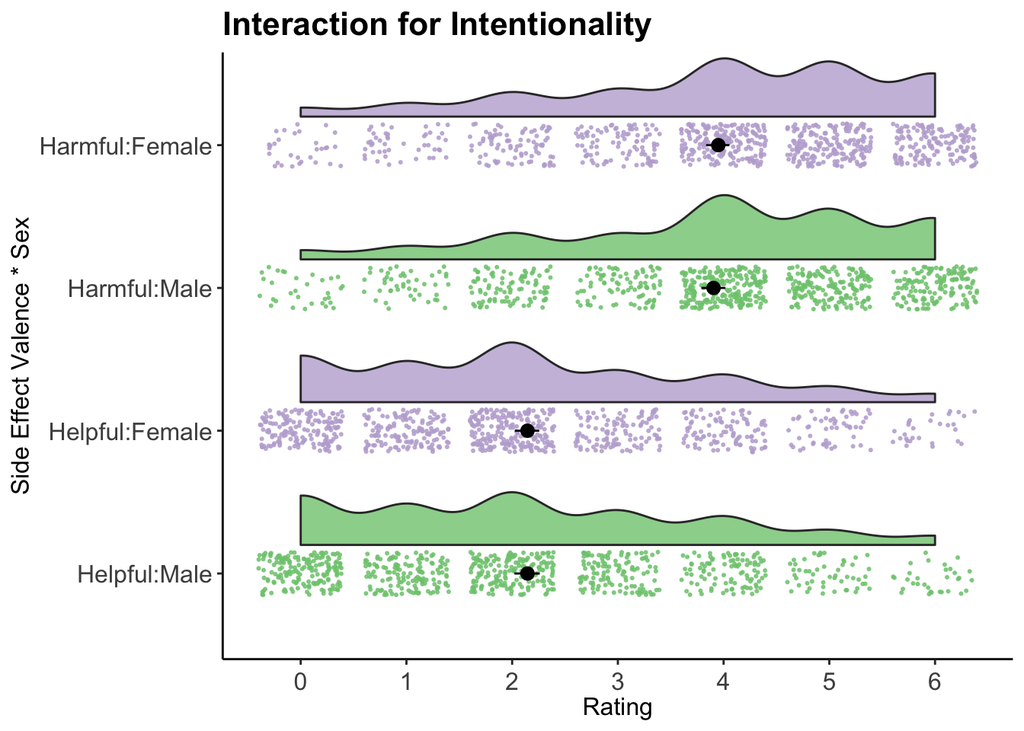

```r
# This is the raincloud plot for the Intentionality model
IntRain <- ggplot(data = PlotData[filterInt2,],
                 aes(y = Rating, x = PlotData[filterInt2,]$SEValence : PlotData[filterInt2,]$Sex, fill = Sex)) +
  geom_flat_violin(position = position_nudge(x = .2, y = 0), alpha = .8, trim=TRUE) +
  geom_point(aes(y = Rating, color = Sex),
             position = position_jitter(width = .15), size = .4, alpha = 0.8) +
  expand_limits(x = 3) +
  guides(fill = FALSE) +
  guides(color = FALSE) +
  scale_color_brewer(palette = "Accent") +
  scale_fill_brewer(palette = "Accent") +
  coord_flip() +
  theme_bw() +
  raincloud_theme +
  labs(x = "Side Effect Valence * Sex", title = "Interaction for Intentionality") +
  scale_y_continuous(breaks = seq(0,6,by = 1)) +
  stat_summary(fun.data = "mean_cl_boot", colour = "black", size =.5)

IntRain
```

# Research Team

This research was conducted by [Bradley Kennedy](https://bradk.co.uk)  
Principal Supervisor: Dr Suzanne L. K. Stewart  
Supervision Team: Dr Annie Scudds & Professor Moira Lafferty

[figure not shown]